# Time series Modelling

## Project Title

Forecasting Nigerian Crude Oil Production and Exports Using Time Series Analysis (2006–2023). A Python-Based Forecasting Model for Understanding Production Trends, Export Performance, and Oil Price Dynamics in Nigeria

```python
#importing required libraries
import pandas as pd
import numpy as np

import matplotlib.pyplot as plt

from statsmodels.tsa.seasonal import seasonal_decompose
from statsmodels.tsa.stattools import adfuller

from statsmodels.tsa.arima.model import ARIMA

from sklearn.metrics import mean_absolute_error
from sklearn.metrics import mean_squared_error

import warnings
warnings.filterwarnings("ignore")
```

```python
#Load Dataset
df = pd.read_csv("CrudeOilProdPrice.csv")

df.head()
```

|  | Year | Month | Crude Oil Price | Production | Crude Oil Export |
| --- | --- | --- | --- | --- | --- |
| 0 | 2006 | 1 | 63.85 | 2.59 | 2.14 |
| 1 | 2006 | 2 | 61.33 | 2.47 | 2.02 |
| 2 | 2006 | 3 | 65.00 | 2.25 | 1.80 |
| 3 | 2006 | 4 | 72.09 | 2.32 | 1.87 |
| 4 | 2006 | 5 | 71.18 | 2.28 | 1.83 |

```python
#Creating a Date Column
df["Date"] = pd.to_datetime(
    df["Year"].astype(str) + "-" +
    df["Month"].astype(str) + "-01"
)

df.set_index("Date", inplace=True)

df.head()
```

| Date | Year | Month | Crude Oil Price | Production | Crude Oil Export |
| --- | --- | --- | --- | --- | --- |
| 2006-01-01 | 2006 | 1 | 63.85 | 2.59 | 2.14 |
| 2006-02-01 | 2006 | 2 | 61.33 | 2.47 | 2.02 |
| 2006-03-01 | 2006 | 3 | 65.00 | 2.25 | 1.80 |
| 2006-04-01 | 2006 | 4 | 72.09 | 2.32 | 1.87 |
| 2006-05-01 | 2006 | 5 | 71.18 | 2.28 | 1.83 |

```python
#Checking  for Missing Values
df.isnull().sum()
```

```
Year                0
Month               0
Crude Oil Price     0
Production          0
Crude Oil Export    0
dtype: int64
```

```python
#Summary Statistics
df.describe()
```

|  | Year | Month | Crude Oil Price | Production | Crude Oil Export |
| --- | --- | --- | --- | --- | --- |
| count | 215.000000 | 215.000000 | 215.000000 | 215.000000 | 215.000000 |
| mean | 2014.460465 | 6.511628 | 78.694884 | 1.979814 | 1.529814 |
| std | 5.179675 | 3.463913 | 25.784642 | 0.398306 | 0.398306 |
| min | 2006.000000 | 1.000000 | 14.280000 | 0.940000 | 0.490000 |
| 25% | 2010.000000 | 3.500000 | 59.890000 | 1.795000 | 1.345000 |
| 50% | 2014.000000 | 7.000000 | 75.110000 | 2.070000 | 1.620000 |
| 75% | 2019.000000 | 9.500000 | 103.030000 | 2.250000 | 1.800000 |
| max | 2023.000000 | 12.000000 | 138.740000 | 2.880000 | 2.430000 |

# Interpretation

The descriptive statistics provide a summary of the distribution of each variable based on 215 monthly observations covering approximately eighteen years. The average crude oil price stood at 78.69 USD/barrel, ranging from a minimum of 14.28 USD/barrel to a maximum of 138.74 USD/barrel; this large range demonstrates the high volatility of global crude oil markets over the study period, reflecting major economic events such as the 2008 financial crisis, the 2014–2016 oil price collapse, and the COVID-19 pandemic. Average production was 1.98 million barrels per day, with a maximum of 2.88 million barrels per day and a minimum of 0.94 million barrels per day; the decline to less than one million barrels per day indicates periods of severe production disruptions that may have resulted from pipeline vandalism, production shutdowns, oil theft, OPEC production quotas, or security challenges in the Niger Delta. Average exports were 1.53 million barrels per day, ranging from a minimum of 0.49 million barrels per day to a maximum of 2.43 million barrels per day, and exports closely mirror production levels, highlighting Nigeria’s dependence on crude oil exports as a major source of foreign exchange. Overall, the descriptive statistics reveal considerable variability across all variables, justifying the need for time series modeling and forecasting.

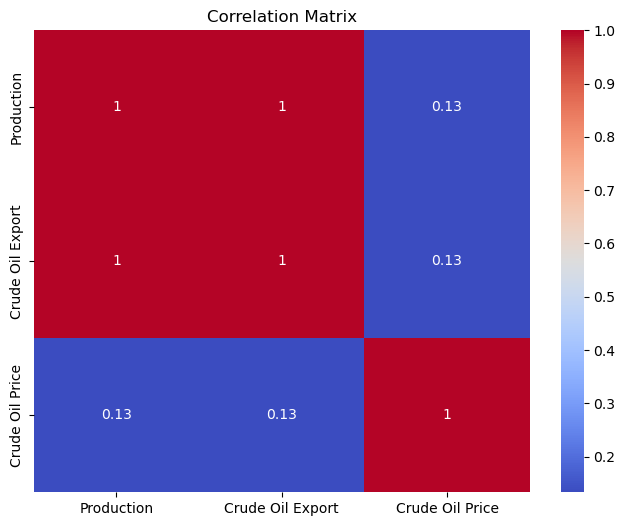

```python
#Correlation Analysis
import seaborn as sns

plt.figure(figsize=(8,6))

sns.heatmap(df[['Production',
                'Crude Oil Export',
                'Crude Oil Price']].corr(),
            annot=True,
            cmap='coolwarm')

plt.title("Correlation Matrix")

plt.show()
```